# Final project starter script

Prof. Chouldechova

#### Variables present in the base data set

To learn more about the data, you can have a look at the [variable codebook file](http://www.andrew.cmu.edu/user/achoulde/94842/final_project/nlsy97/nlsy97_codebook.txt).

Here’s how to rename all the variables to the Question Name abbreviation. **You will want to change the names to be even more descriptive**, but this is a start.

This section of the report analyses association between the variables income (income), sex (sex) with marital status of the respondent (marital.status), number of household members (household.size) and the number of houshold members under 18 (household.under18).

The purpose of this evaluation is to understand how the difference in the income between men and women in the dataset varies across groups with different marital statuses, household sizes and number of household members under 18 and to check for any association between them.

#### Getting to know our two main variables.

In the previous chunk of code we have appropriately renamed the variables corresponding to `sex`, `race`,`marital.status`, `household.size` `income` (as reported on the 2017 survey). Let’s have a quick look at what we’re working with.

Statistical summary for variable sex

| Var1 | Freq |
| --- | --- |
| 1 | 4599 |
| 2 | 4385 |

```
##    Min. 1st Qu.  Median    Mean 3rd Qu.    Max.
##   1.000   1.000   1.000   1.488   2.000   2.000
```

Statistical summary for variable race

| Var1 | Freq |
| --- | --- |
| 1 | 2335 |
| 2 | 1901 |
| 3 | 83 |
| 4 | 4665 |

```
##    Min. 1st Qu.  Median    Mean 3rd Qu.    Max.
##   1.000   1.000   4.000   2.788   4.000   4.000
```

Statistical summary for variable marital status

| Var1 | Freq |
| --- | --- |
| -5 | 2250 |
| -3 | 62 |
| 0 | 2766 |
| 1 | 3066 |
| 2 | 154 |
| 3 | 663 |
| 4 | 23 |

```
##    Min. 1st Qu.  Median    Mean 3rd Qu.    Max.
## -5.0000 -5.0000  0.0000 -0.6657  1.0000  4.0000
```

Statistical summary for variable house hold size

| Var1 | Freq |
| --- | --- |
| -5 | 1561 |
| 1 | 938 |
| 2 | 1845 |
| 3 | 1684 |
| 4 | 1455 |
| 5 | 841 |
| 6 | 359 |
| 7 | 172 |
| 8 | 68 |
| 9 | 36 |
| 10 | 12 |
| 11 | 7 |
| 12 | 3 |
| 13 | 1 |
| 15 | 2 |

```
##    Min. 1st Qu.  Median    Mean 3rd Qu.    Max.
##  -5.000   1.000   3.000   1.826   4.000  15.000
```

Statistical summary for variable number of house hold members under 18 years age

[output not shown]

```
##     Min.  1st Qu.   Median     Mean  3rd Qu.     Max.
## -5.00000  0.00000  0.00000  0.01202  2.00000  9.00000
```

#Recoding for variables

You’ll want to do some data manipulations to change away from the numeric codings to more interpretable labels.

```
##    Min. 1st Qu.  Median    Mean 3rd Qu.    Max.
##      -5      -5   14000   28035   45000  235884
```

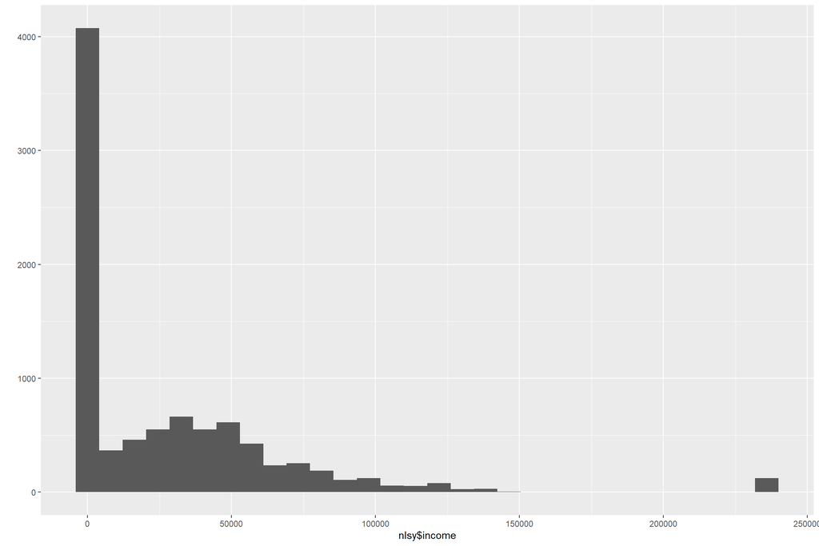

```
## # A tibble: 2 x 3
##   sex      mean     sd
##   <fct>   <dbl>  <dbl>
## 1 Male   32598. 44062.
## 2 Female 23250. 32744.
```

*Income*

The income distributing is right-skewed like one might expect. However, as indicated in the question description, the income variable is *topcoded* at the 2% level. More precisely,

```
## [1] 121
```